# Non-photochemical quenching (NPQ) of phytoplankton in the Mid-Atlantic coastal ocean

Seagoing project aboard the R/V *Hugh R. Sharp* over the course of 12 months  
2008-2009

Authors

Affiliation

M.J. Oliver

University of Delaware

M.D. Grossi

University of Delaware

E.F. Geiger

University of Delaware

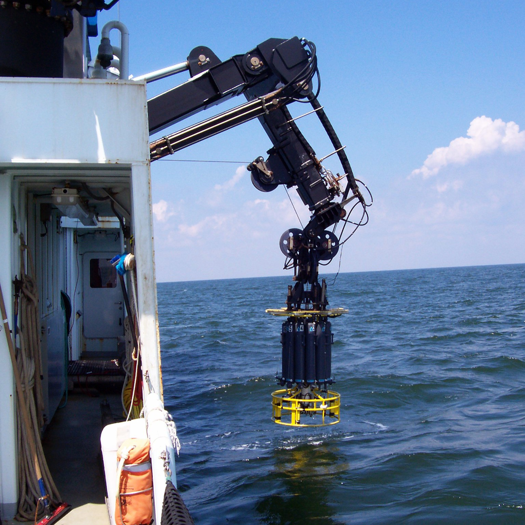

A Conductivity-Temperature-Depth (CTD) rosette sampler deployed off the R/V *Hugh R. Sharp*. Photo by M.D. Grossi.

Part of a broader funded project entitled “Mapping photosynthetic quantum yield in the coastal ocean,” this work investigated a physiological phenomonon in marine phytoplankton called non-photochemical quenching (NPQ), a means by which phytoplankton protect themselves from too much sunlight. Think natural sunscreen.

The project involved twelve week-long cruises (one per month) along the mid-Atlantic bight from Delaware Bay north along the New Jersey coast. Carried out on the Universitiy of Delaware’s [UNOLS](https://www.unols.org/) research vessel [R/V *Hugh R. Sharp*](https://www.udel.edu/content/dam/udelImages/ceoe/documents/marine-operations/rvSharp-Overview-Jan-2018_long.pdf), we sampled continuously for phytoplankton maximum quantum yield using a Fluorescence Induction and Relaxation (FIRe) system, ocean particle size distribution and counts using a Coulter Counter, surface nutrients using a Submersible Ultraviolet Nitrate Analyzer (SUNA), solar irradiance, sea surface temperature, and surface salinity.

### Poster

1. Treible, L.M., E.F. Geiger, **Grossi, M.D.**, M.J. Oliver (2010) The Impact of Wind on Non-Photochemical Quenching in the Mid-Atlantic Coastal Ocean, 2010 Ocean Sciences Meeting, February 22-26, 2010, Portland, OR.